# Part II — Explanatory Data Visualization

This project has two parts that demonstrate the importance and value of data visualization techniques in the data analysis process.

1. In Part I, Exploratory data visualization, you will use Python visualization libraries to systematically explore a selected dataset, starting from plots of single variables and building up to plots of multiple variables.
2. In Part II, Explanatory data visualization, you will produce a short presentation that illustrates interesting properties, trends, and relationships that you discovered in your selected dataset. The primary method of conveying your findings will be through transforming your exploratory visualizations from the first part into polished, explanatory visualizations.

Each part is saved in its own notebook and summary output.

```python
# Import libraries
import numpy as np
import pandas as pd
import matplotlib.pyplot as plt
import seaborn as sns

%matplotlib inline

sns.set_theme(style="whitegrid")
```

```python
# Load dataset
loan_df = pd.read_csv("prosperLoanData.csv")

loan_df.shape
```

```
(113937, 81)
```

```python
loan_df.head()
```

|  | ListingKey | ListingNumber | ListingCreationDate | CreditGrade | Term | LoanStatus | ClosedDate | BorrowerAPR | BorrowerRate | LenderYield | ... | LP_ServiceFees | LP_CollectionFees | LP_GrossPrincipalLoss | LP_NetPrincipalLoss | LP_NonPrincipalRecoverypayments | PercentFunded | Recommendations | InvestmentFromFriendsCount | InvestmentFromFriendsAmount | Investors |
| --- | --- | --- | --- | --- | --- | --- | --- | --- | --- | --- | --- | --- | --- | --- | --- | --- | --- | --- | --- | --- | --- |
| 0 | 1021339766868145413AB3B | 193129 | 2007-08-26 19:09:29.263000000 | C | 36 | Completed | 2009-08-14 00:00:00 | 0.16516 | 0.1580 | 0.1380 | ... | -133.18 | 0.0 | 0.0 | 0.0 | 0.0 | 1.0 | 0 | 0 | 0.0 | 258 |
| 1 | 10273602499503308B223C1 | 1209647 | 2014-02-27 08:28:07.900000000 | NaN | 36 | Current | NaN | 0.12016 | 0.0920 | 0.0820 | ... | 0.00 | 0.0 | 0.0 | 0.0 | 0.0 | 1.0 | 0 | 0 | 0.0 | 1 |
| 2 | 0EE9337825851032864889A | 81716 | 2007-01-05 15:00:47.090000000 | HR | 36 | Completed | 2009-12-17 00:00:00 | 0.28269 | 0.2750 | 0.2400 | ... | -24.20 | 0.0 | 0.0 | 0.0 | 0.0 | 1.0 | 0 | 0 | 0.0 | 41 |
| 3 | 0EF5356002482715299901A | 658116 | 2012-10-22 11:02:35.010000000 | NaN | 36 | Current | NaN | 0.12528 | 0.0974 | 0.0874 | ... | -108.01 | 0.0 | 0.0 | 0.0 | 0.0 | 1.0 | 0 | 0 | 0.0 | 158 |
| 4 | 0F023589499656230C5E3E2 | 909464 | 2013-09-14 18:38:39.097000000 | NaN | 36 | Current | NaN | 0.24614 | 0.2085 | 0.1985 | ... | -60.27 | 0.0 | 0.0 | 0.0 | 0.0 | 1.0 | 0 | 0 | 0.0 | 20 |

5 rows × 81 columns

```python
loan_df.info()
```

```
<class 'pandas.core.frame.DataFrame'>
RangeIndex: 113937 entries, 0 to 113936
Data columns (total 81 columns):
 #   Column                               Non-Null Count   Dtype
---  ------                               --------------   -----
 0   ListingKey                           113937 non-null  object
 1   ListingNumber                        113937 non-null  int64
 2   ListingCreationDate                  113937 non-null  object
 3   CreditGrade                          28953 non-null   object
 4   Term                                 113937 non-null  int64
 5   LoanStatus                           113937 non-null  object
 6   ClosedDate                           55089 non-null   object
 7   BorrowerAPR                          113912 non-null  float64
 8   BorrowerRate                         113937 non-null  float64
 9   LenderYield                          113937 non-null  float64
```

[output cut: 73 more lines]

```python
# Select important columns for the analysis
selected_columns = [
    "LoanOriginalAmount",
    "BorrowerRate",
    "LoanStatus",
    "IncomeRange",
    "EmploymentStatus",
    "CreditScoreRangeUpper",
    "DebtToIncomeRatio"
]

loan_df = loan_df[selected_columns].copy()
```

```python
# Check missing values
loan_df.isnull().sum()
```

```
LoanOriginalAmount          0
BorrowerRate                0
LoanStatus                  0
IncomeRange                 0
EmploymentStatus         2255
CreditScoreRangeUpper     591
DebtToIncomeRatio        8554
dtype: int64
```

```python
# Drop rows with missing values in important columns
loan_df = loan_df.dropna(subset=[
    "LoanOriginalAmount",
    "BorrowerRate",
    "LoanStatus",
    "IncomeRange",
    "CreditScoreRangeUpper"
])
```

```python
# Remove invalid income values
loan_df = loan_df[
    ~loan_df["IncomeRange"].isin(["Not displayed", "Not employed", "$0"])
]
```

```python
# Convert BorrowerRate to percentage
loan_df["BorrowerRatePercent"] = loan_df["BorrowerRate"] * 100
```

```python
# Define income order
income_order = [
    "$1-24,999",
    "$25,000-49,999",
    "$50,000-74,999",
    "$75,000-99,999",
    "$100,000+"
]

loan_df["IncomeRange"] = pd.Categorical(
    loan_df["IncomeRange"],
    categories=income_order,
    ordered=True
)
```

```python
def add_title_labels(title, xlabel, ylabel):
    plt.title(title, fontsize=14, weight="bold")
    plt.xlabel(xlabel)
    plt.ylabel(ylabel)
    plt.tight_layout()
```

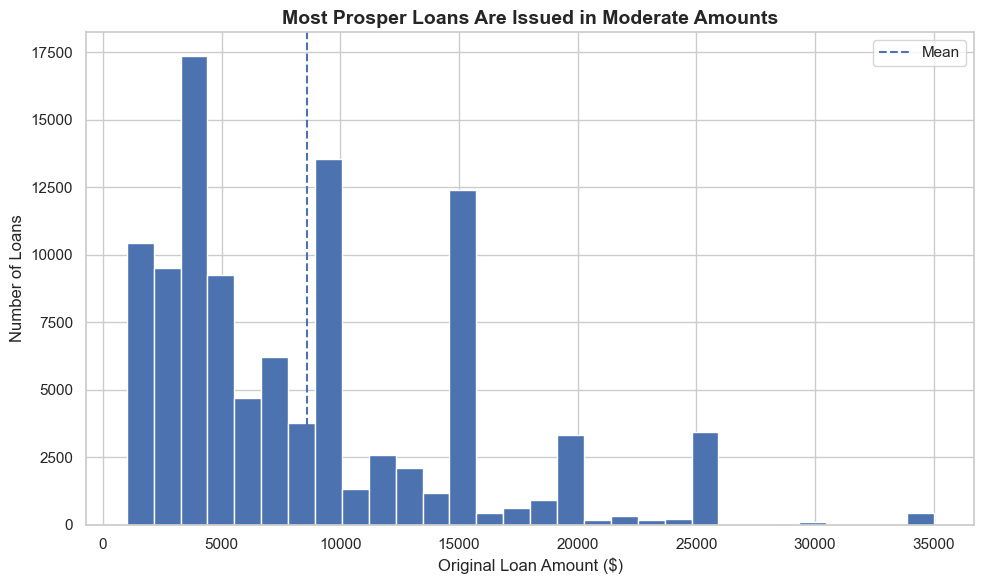

```python
plt.figure(figsize=(10, 6))

plt.hist(
    data=loan_df,
    x="LoanOriginalAmount",
    bins=30
)

plt.axvline(
    loan_df["LoanOriginalAmount"].mean(),
    linestyle="--",
    label="Mean"
)

add_title_labels(
    "Most Prosper Loans Are Issued in Moderate Amounts",
    "Original Loan Amount ($)",
    "Number of Loans"
)

plt.legend()
plt.show()
```

Most Prosper loans are issued in moderate amounts, with the majority falling below $15,000. The right-skewed distribution indicates that larger loans are less common.

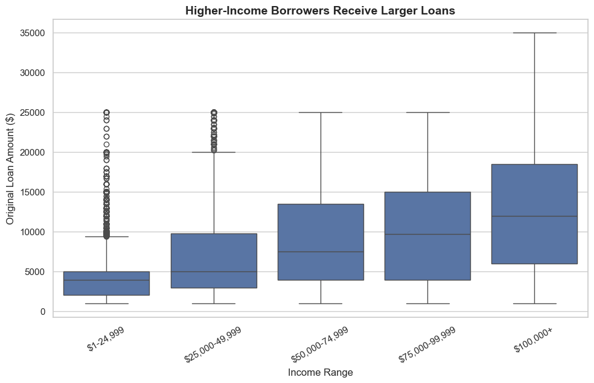

```python
plt.figure(figsize=(10, 6))

sns.boxplot(
    data=loan_df,
    x="IncomeRange",
    y="LoanOriginalAmount",
    order=income_order
)

add_title_labels(
    "Higher-Income Borrowers Receive Larger Loans",
    "Income Range",
    "Original Loan Amount ($)"
)

plt.xticks(rotation=30)
plt.show()
```

Higher-income borrowers consistently receive larger loans. The median loan amount increases substantially across income brackets, demonstrating that income is a strong predictor of borrowing capacity.

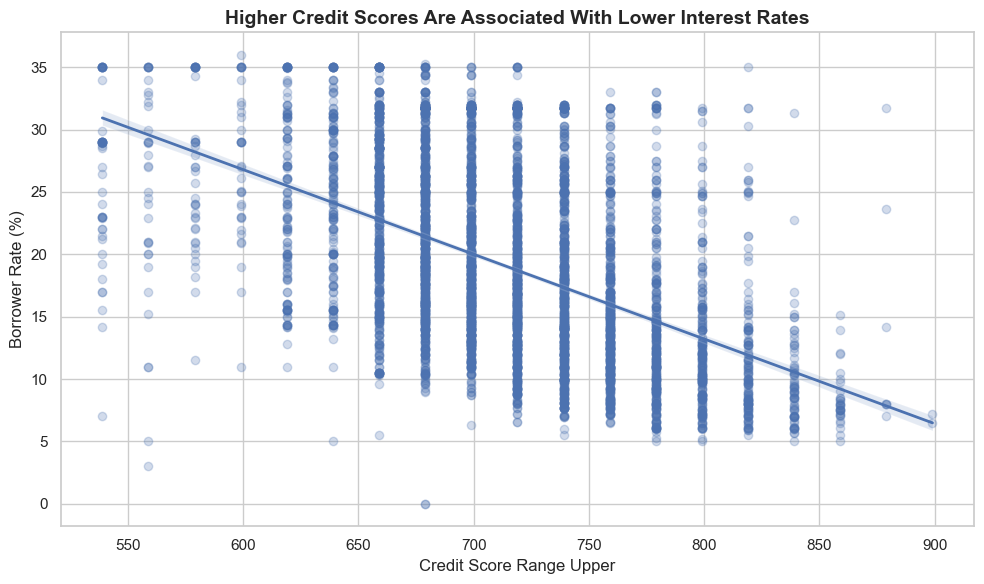

```python
plt.figure(figsize=(10, 6))

sns.regplot(
    data=sample_df,
    x="CreditScoreRangeUpper",
    y="BorrowerRatePercent",
    scatter_kws={"alpha": 0.25},
    line_kws={"linewidth": 2}
)

add_title_labels(
    "Higher Credit Scores Are Associated With Lower Interest Rates",
    "Credit Score Range Upper",
    "Borrower Rate (%)"
)

plt.show()
```

A strong negative relationship exists between credit score and borrower interest rate. Borrowers with higher credit scores benefit from significantly lower interest rates, reflecting the financial risk premium applied to lower-credit borrowers.

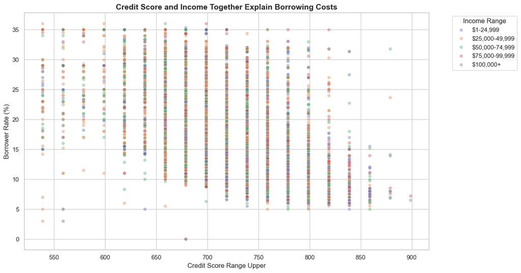

```python
plt.figure(figsize=(11, 7))

sns.scatterplot(
    data=facet_sample,
    x="CreditScoreRangeUpper",
    y="BorrowerRatePercent",
    hue="IncomeRange",
    alpha=0.4
)

add_title_labels(
    "Credit Score and Income Together Explain Borrowing Costs",
    "Credit Score Range Upper",
    "Borrower Rate (%)"
)

plt.legend(
    title="Income Range",
    bbox_to_anchor=(1.05, 1),
    loc="upper left"
)

plt.show()
```

# Conclusions

This investigation explored factors associated with loan amounts and borrower interest rates in the Prosper Loan Dataset.

Overall, credit score appears to be the strongest predictor of borrowing cost, while income plays an important role in determining loan size. These findings provide a foundation for the explanatory analysis, which focuses on how borrower financial characteristics influence loan outcomes and borrowing conditions.